# Content based movie recommender Antonia

### Bibliotheken laden

```r
library(tidyverse)
library(dplyr)
library(data.table)
library(recommenderlab)
library(viridis)
source("MC2_Antonia.R")
```

### 7.1 Erzeugung von Film- & Nutzerprofilen [20 Punkte]

Für die Film- und Nutzerprofile verwenden wir den MovieLense Datensatz von Recommenderlab.

Für die Nutzer:innen haben wir eine Matrix mit allen gerateten Filmen. Um Empfehlungen zu machen, wandeln wir die Ratings um; für alle Ratings die grösser als 3 sind setzen wir eine 1 (= der Film hat gefallen).

Idealerweise sollten wir natürlich statt einem fixen Masstab für alle Nutzer:innen lieber die Werte normieren, sprich jeden Wert um das durchschnittliche Rating des Nutzers korrigieren und dann die positiven Werte als Likes nehmen. So würden wir auch das individuelle Rating-Verhalten der Nutzer:innen berücksichtigen.

#### 1. MovieLense Daten einlesen

```r
data(MovieLense)
df_user_ratings <- as.data.frame(as(MovieLense, "matrix"))
```

#### 2. Binäre User-Liked-Items Matrix für alle Nutzer erzeugen

```r
df_user_liked_items <- ifelse(df_user_ratings >3 ,1,0)
```

#### 3. Dimension der User-Liked-Items Matrix prüfen und ausgeben

```r
dim(df_user_liked_items)
```

```
## [1]  943 1664
```

Die Matrix enthält 943 User und 1664 Items.

#### 4. Movie-Genre Matrix für alle Filme erzeugen

```r
df_movie_genre <- as.data.frame(MovieLenseMeta)
rownames(df_movie_genre) <- df_movie_genre$title
df_movie_genre <- df_movie_genre %>% select(-c("year", "url", "title"))

m_movie_genre <- as(df_movie_genre, "matrix")

head(m_movie_genre)
```

```
##                                                      unknown Action Adventure
## Toy Story (1995)                                           0      0         0
## GoldenEye (1995)                                           0      1         1
## Four Rooms (1995)                                          0      0         0
## Get Shorty (1995)                                          0      1         0
## Copycat (1995)                                             0      0         0
## Shanghai Triad (Yao a yao yao dao waipo qiao) (1995)       0      0         0
##                                                      Animation Children's
## Toy Story (1995)                                             1          1
## GoldenEye (1995)                                             0          0
## Four Rooms (1995)                                            0          0
## Get Shorty (1995)                                            0          0
## Copycat (1995)                                               0          0
## Shanghai Triad (Yao a yao yao dao waipo qiao) (1995)         0          0
##                                                      Comedy Crime Documentary
## Toy Story (1995)                                          1     0           0
## GoldenEye (1995)                                          0     0           0
## Four Rooms (1995)                                         0     0           0
## Get Shorty (1995)                                         1     0           0
## Copycat (1995)                                            0     1           0
## Shanghai Triad (Yao a yao yao dao waipo qiao) (1995)      0     0           0
##                                                      Drama Fantasy Film-Noir
## Toy Story (1995)                                         0       0         0
## GoldenEye (1995)                                         0       0         0
## Four Rooms (1995)                                        0       0         0
## Get Shorty (1995)                                        1       0         0
## Copycat (1995)                                           1       0         0
## Shanghai Triad (Yao a yao yao dao waipo qiao) (1995)     1       0         0
##                                                      Horror Musical Mystery
## Toy Story (1995)                                          0       0       0
## GoldenEye (1995)                                          0       0       0
## Four Rooms (1995)                                         0       0       0
## Get Shorty (1995)                                         0       0       0
## Copycat (1995)                                            0       0       0
## Shanghai Triad (Yao a yao yao dao waipo qiao) (1995)      0       0       0
##                                                      Romance Sci-Fi Thriller
## Toy Story (1995)                                           0      0        0
## GoldenEye (1995)                                           0      0        1
## Four Rooms (1995)                                          0      0        1
## Get Shorty (1995)                                          0      0        0
## Copycat (1995)                                             0      0        1
## Shanghai Triad (Yao a yao yao dao waipo qiao) (1995)       0      0        0
##                                                      War Western
## Toy Story (1995)                                       0       0
## GoldenEye (1995)                                       0       0
## Four Rooms (1995)                                      0       0
## Get Shorty (1995)                                      0       0
## Copycat (1995)                                         0       0
## Shanghai Triad (Yao a yao yao dao waipo qiao) (1995)   0       0
```

```r
print(paste("Dimensionen Movie-Genre Matrix:", dim(m_movie_genre)[1], dim(m_movie_genre)[2]))
```

```
## [1] "Dimensionen Movie-Genre Matrix: 1664 19"
```

Die Matrix enthält 1664 Filme und 19 Genres.

#### 6. Anzahl unterschiedlicher Filmprofile bestimmen und visualisieren

Als nächstes schauen wir uns für jeden Film an, zu welchen Genres er gehört und erstellen so ein ganz individuelles Filmprofil. Da hier nur pro Genre ein Wert ist müssen wir nicht noch durch die Anzahl Genres teilen um das exakte Profil zu erhalten, da jedes Genre nur 1x enthalten sein kann.

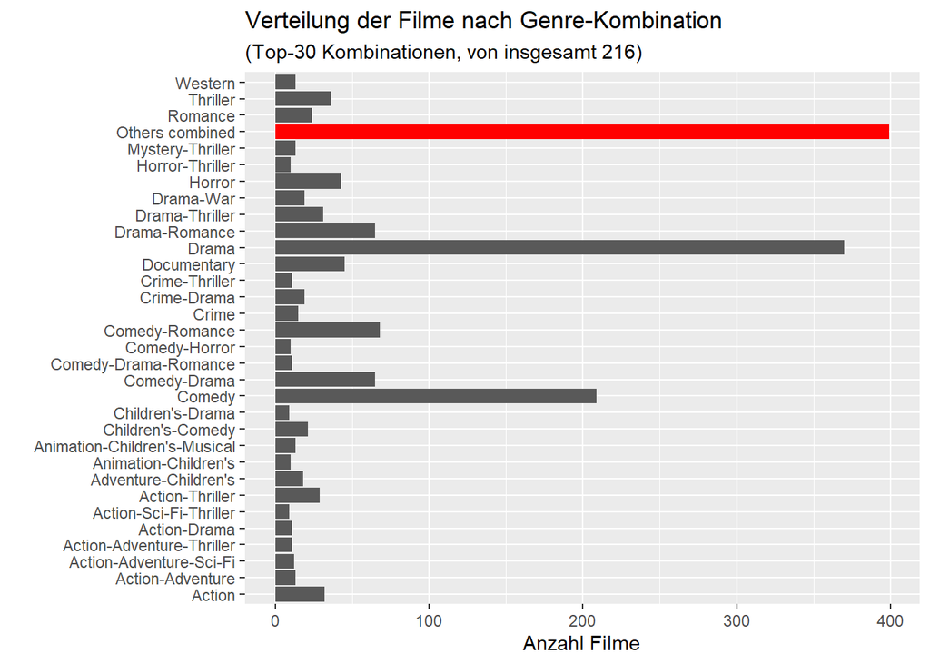

```r
#ChatGPT genutzt um die Genre-Kombinationen zu erhalten. Prompt: "I am working with the MovieLense dataframe and I need to modify the MovieLenseMeta dataframe to have an additional column with the combination of genres. So if a movie has "Action" and "Adventure" as their genres, the column should have "Action-Adventure" as value. can you help me write this code?" Resultat davon ist der Code für die Spalte "movie_profiles". Im Original wollte ChatGPT für die Genres einen Vektor schreiben mit den expliziten Genre-Namen und die Funktion nur auf diese Spalten anwenden. Da das aber ohnehin alle Spalten sind war das ein unnötiger Mehraufwand.

df_movie_genre$movie_profile <- apply(df_movie_genre, 1, function(row) {
  paste(names(row)[row == 1], collapse = '-')
})

df_genres_count <-  as.data.frame(table(df_movie_genre$movie_profile, dnn = "genre"))

n_single_genres <- df_genres_count %>% filter(Freq == 1) %>% count()

df_top30 <-df_genres_count %>%  slice_max(n = 30, order_by = Freq)
df_rest <- df_genres_count %>%
  filter(!(genre %in% df_top30$genre)) %>%
  summarise("Freq" = sum(Freq)) %>%
  mutate(genre = "Others combined")

ggplot()+
  geom_col(data = df_top30, aes(Freq, genre))+
  geom_col(data = df_rest, aes(Freq, genre), fill = "red")+
  labs(y = "",
       x = "Anzahl Filme",
       title = "Verteilung der Filme nach Genre-Kombination",
       subtitle = paste0("(Top-30 Kombinationen, von insgesamt ", toString(dim(df_genres_count)[1]), ")"))
```

Insgesamt haben wir 216 unterschiedliche Genre-Kombinationen, wobei 100 eine einzigartige Kombi sind die nur jeweils 1 Film hat.

Wir sehen, dass Drama das häufigste Genre ist, gefolgt von Comedy. Comedy ist allgemein eine beliebte Kombination; gleich 5 der Top 30 Kombinationen enthalten Comedy (6 wenn man Comedy selber mitzählt). Beliebter ist nur noch Action, mit insgesamt 6 resp. 7 Kombinationen in den Top 30. Wenn wir noch zum Vergleich die Häufigkeit für die nicht kombinierten Genres anschauen (nächster Plot) sehen wir, dass sich die Kombinationen dort spiegeln: auch hier ist Drama, gefolgt von Comedy das häufigste Genre.

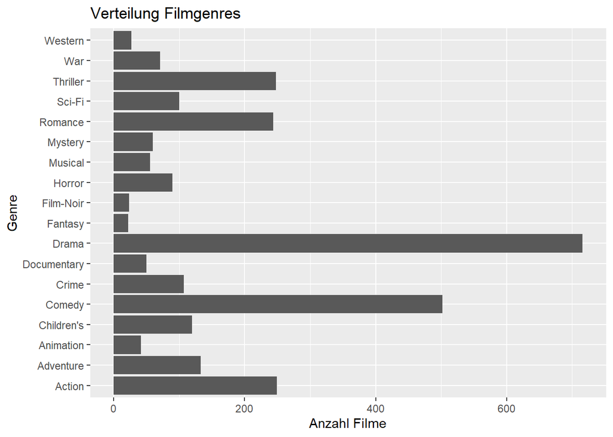

```r
df_genres_count2 <- rownames_to_column(as.data.frame(colSums(df_movie_genre[2:19])))
colnames(df_genres_count2) <- c("genre", "count")
ggplot(df_genres_count2, aes(count, genre))+
  geom_col()+
  labs(title= "Verteilung Filmgenres",
       x = "Anzahl Filme",
       y = "Genre")
```

#### 7. Nutzerprofile im Genre-Vektorraum erzeugen

Als nächstes schauen wir uns an, welche Genres die Nutzer:innen gerne schauen. Dazu verwenden wir den Datensatz mit den User-liked-movies und multiplizieren diesen mithilfe einer Matrix-Multiplikation mit der Film-Genre Matrix. Wir prüfen auch hier die Dimensionen (diese müssten Anzahl User x Anzahl Genres entsprechen). Man könnte hier noch anstatt der Zählung der Genres pro User zu nehmen diese noch durch die Anzahl aller Ratings des Users dividieren, um ein noch genaueres Profil zu erhalten. Um einen Eindruck eines Profils zu erhalten reicht es aber, die Zählung der Genres zu machen.

```r
#movie - Filmprofil Matrix
movie_profiles <- rownames_to_column(df_movie_genre, "movie") %>%
  select(movie, movie_profile) %>%
  mutate(value = 1) %>%
  pivot_wider(id_cols = movie,names_from = movie_profile, values_from = value, values_fill = 0) %>%
  column_to_rownames(var = "movie")

#Dataframes in Matrizen umwandeln
m_movie_profiles <- as(movie_profiles, "matrix")
m_user_liked <- as(df_user_liked_items, "matrix")
m_user_liked[is.na(m_user_liked)] <- 0


#Matrixmultiplikation
m_user_genre <- m_user_liked %*% m_movie_genre

head(m_user_genre)
```

```
##   unknown Action Adventure Animation Children's Comedy Crime Documentary Drama
## 1       1     39        17         5          5     49    15           5    77
## 2       0      7         3         1          2     12     6           0    22
## 3       0      3         2         0          0      3     3           1     7
## 4       0      5         2         0          0      4     4           1     4
## 5       1     23        14         8          5     33     7           0     7
## 6       0     14        13         6          8     39     9           1    68
##   Fantasy Film-Noir Horror Musical Mystery Romance Sci-Fi Thriller War Western
## 1       1         1      7       6       3      29     32       30  15       3
## 2       0         2      0       0       1      13      2        6   2       0
## 3       0         0      0       0       4       2      2        4   2       0
## 4       0         0      1       1       3       2      4        7   2       0
## 5       1         1      8       4       1       6     19        5   7       1
## 6       0         6      3       8      11      27      7       18  15       3
```

Auf den ersten Blick sieht es gut aus;die Einträge sehen so aus wie wir sie erwarten.

Wenn wir nun wieder ein Histogram machen mit den Anzahl Likes pro Genre ist das Bild sehr ähnlich wie die Verteilung bei den Filmen:

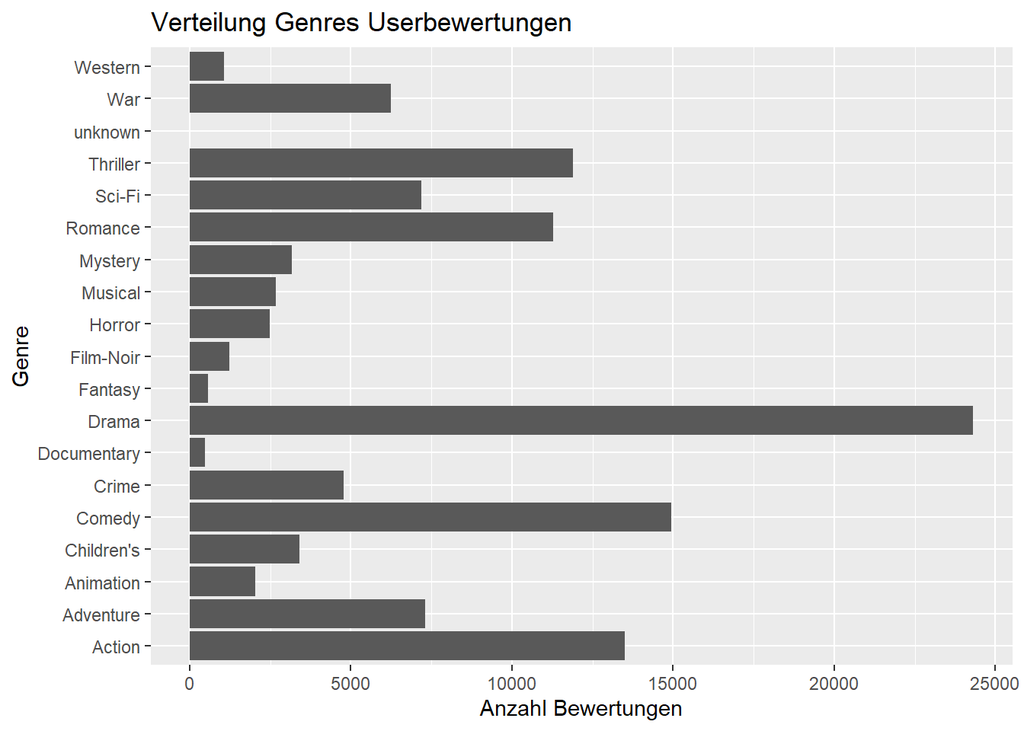

```r
df_user_genres_count <- rownames_to_column(as.data.frame(colSums(m_user_genre)))
colnames(df_user_genres_count) <- c("genre", "count")
ggplot(df_user_genres_count, aes(count, genre))+
  geom_col()+
  labs(title= "Verteilung Genres Userbewertungen",
       x = "Anzahl Bewertungen",
       y = "Genre")
```

Auch hier ist Drama der Spitzenreiter, gefolgt von Comedy und Action.

In den Genre-Kombinationen finden wir ebenfalls in etwa die gleiche Verteilung wie bei den Filmen - er scheint also auch mit der Anzahl Ratings kein Umverteilen der Reihenfolge der Beliebtheit zu geben:

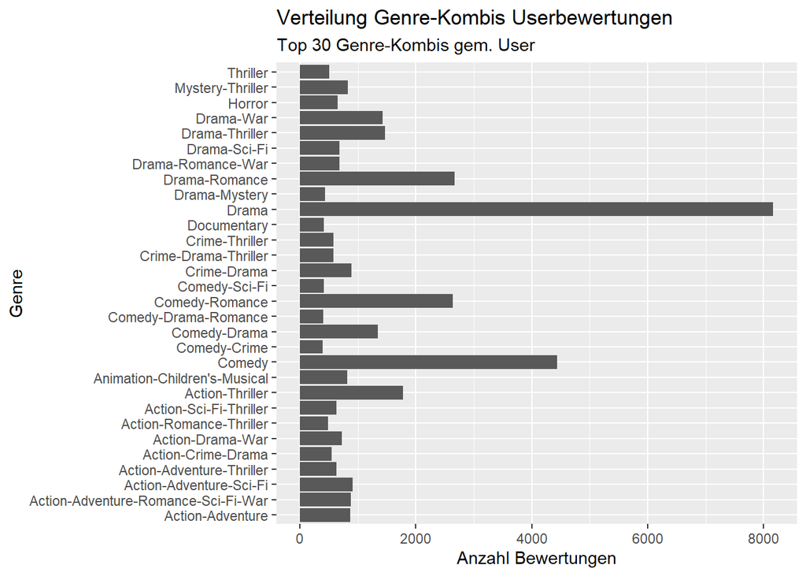

```r
## Grafik mit Movie Profilen statt nur Genres
m_user_movie_profile <- m_user_liked %*% m_movie_profiles

df_user_mprofile_count <- rownames_to_column(as.data.frame(colSums(m_user_movie_profile)))
colnames(df_user_mprofile_count) <- c("genre", "count")
df_user_mprofile_count %>% slice_max(order_by = count, n = 30) %>%
ggplot(aes(count, genre))+
  geom_col()+
  labs(title= "Verteilung Genre-Kombis Userbewertungen",
       subtitle = "Top 30 Genre-Kombis gem. User",
       x = "Anzahl Bewertungen",
       y = "Genre")
```

```r
print(paste("Dimensionen der User-Genre Matrix:", dim(m_user_genre)[1], dim(m_user_genre)[2]))
```

```
## [1] "Dimensionen der User-Genre Matrix: 943 19"
```

Nach der Matrixmultiplikation haben wir weiterhin 943 User und 19 Genre-Profile. Die Multiplikation scheint also korrekt verlaufen zu sein.

#### 9. Anzahl unterschiedlicher Nutzerprofile bestimmen mit Stärke der Genre-Kombination

Als nächstes wollen wir schauen, wie einzigartig die Nutzerprofile sind. Dazu schauen wir an, wie viele Reihen im Datensatz von Nutzer-Genre identisch sind:

```r
#vollständig: Anzahl unique Reihen
print(paste("Anzahl unterschiedlicher Profile mit Stärke der Genres:",dim(unique(m_user_genre))[1]))
```

```
## [1] "Anzahl unterschiedlicher Profile mit Stärke der Genres: 943"
```

```r
#Binär: Anzahl unique Reihen aber mit mutierten Ratings:
print(paste("Anzahl unterschiedlicher Profile binäre Genres:",dim(distinct(as.data.frame(m_user_genre) %>% mutate(across(.cols = everything(), .fns = ~ ifelse(.x > 0, 1, 0)))))[1]))
```

```
## [1] "Anzahl unterschiedlicher Profile binäre Genres: 381"
```

Wenn die Stärke der Genres berücksichtigt wird (also die Anzahl Filme für jedes Genre), so haben alle Nutzer:innen ein einzigartiges Profil, da die Dimensionen der einzigartigen Reihen 943 ist, was der Anzahl Nutzer:innen entspricht. Wenn wir jedoch die Zählung der einzelnen Genres weglassen und nur ein binär “mag Genre ja/nein” vergeben, sind es deutlich weniger einzigartige Profile; 381, was einer Reduktion von 60% entspricht.

### 7.2 Ähnlichkeit von Nutzern und Filmen [10 Punkte]

Als nächstes wollen wir die Cosine-Ähnlichkeit zwischen Filmen und Nutzer:innen bestimmen. Dazu verwenden wir wieder nur die reinen Genres und nicht die Kombinationen. Bei der cosine Similarity wird die Ähnlichkeit zwischen zwei Vektoren berechnet.

#### 1. Cosinus-Ähnlichkeit zwischen User-Genre- und Movie-Genre-Matrix berechnen

##### Testen der Funktion anhand eines einfachen Beispiels

Zur Überprüfung meiner Funktion habe ich ein sehr einfaches Beispiel gemacht welches zu funktionieren scheint; die Cosine-Similarity der beiden Matrizen sieht gut aus; die Diagnonalelemente sind identisch bei der Multiplikation und die Ähnlichkeit zwischen 2 und 3 muss auch sehr hoch sein.

```r
m1 <- matrix(1:4, nrow = 2, ncol = 2)
m2 <- matrix(1:4, nrow = 2, ncol = 2)

print("Matrix 1:")
```

```
## [1] "Matrix 1:"
```

```r
m1
```

```
##      [,1] [,2]
## [1,]    1    3
## [2,]    2    4
```

```r
print("Matrix 2:")
```

```
## [1] "Matrix 2:"
```

```r
m2
```

```
##      [,1] [,2]
## [1,]    1    3
## [2,]    2    4
```

```r
print("Cosine-Ähnlichkeit der beiden Matrizen:")
```

```
## [1] "Cosine-Ähnlichkeit der beiden Matrizen:"
```

```r
calc_cos_similarity_twomx(m1,m2)
```

```
##           [,1]      [,2]
## [1,] 1.0000000 0.9899495
## [2,] 0.9899495 1.0000000
```

#### 2. Dimension der Matrix der Cosinus-Ähnlichkeiten von Nutzern und Filmen prüfen uns ausgeben.

Mithilfe der Funktion berechnen wir nun die Cosine-Similarity zwischen der Film-Genre Matrix und der User-Genre Matrix.

```r
m_csim_user_movie <- calc_cos_similarity_twomx(m_user_genre, m_movie_genre)

print(paste("Dimensionen der Cosinus-Matrix:",dim(m_csim_user_movie)[1],dim(m_csim_user_movie)[2] ))
```

```
## [1] "Dimensionen der Cosinus-Matrix: 943 1664"
```

#### 3. 5-Zahlen Statistik für Matrix der Cosinus-Ähnlichkeiten prüfen uns ausgeben

Mit der Funktion schauen wir uns die Verteilung der Ähnlichkeiten an und die NAs:

```r
stats(m_csim_user_movie)
```

| Min | 25% | Median | 75% | Max | Mean | NAs |
| --- | --- | --- | --- | --- | --- | --- |
| 0 | 0.2300219 | 0.4070324 | 0.5919163 | 0.9767817 | 0.4098111 | 1664 |

#### 4. Cosinus-Ähnlichkeiten von Nutzern und Filmen mit Dichteplot visualisieren.

Wenn wir den Dichteplot anschauen, sehen wir, dass es eine Häufung der Ähnlichkeiten zwischen 0.25 und 0.6 gibt, wobei wir auch sehr viele Werte haben die 0 sind (keinerlei Ähnlichkeit). Wie zu erwarten nimmt die Dichte der Ähnlichkeiten ab je höher sie wird - wir haben also wenige User, deren Genre-Geschmack sehr ähnlich ist zu den vorhanden Film-Genre-Profilen.

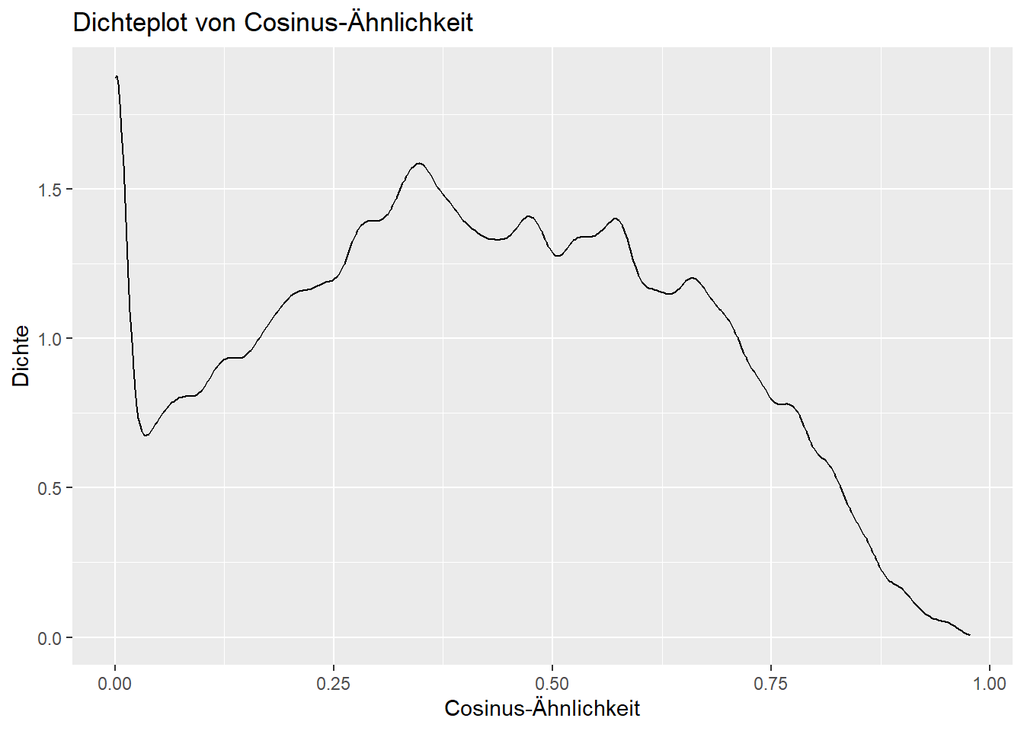

```r
df_csim_long <- rownames_to_column(as.data.frame(m_csim_user_movie), "user") %>%
  pivot_longer(!user, names_to = "movie", values_to = "value")

ggplot(df_csim_long, aes(value))+
  geom_density()+
  labs(title = "Dichteplot von Cosinus-Ähnlichkeit",
       x = "Cosinus-Ähnlichkeit",
       y = "Dichte")
```

#### 5. Cosinus-Ähnlichkeiten von Nutzern und Filmen mit Dichteplot für Nutzer “241”, “414”, “477”, “526”,“640” und “710” visualisieren.

Als nächstes wollen wir die Dichtekurven von bestimmten Nutzer:innen anschauen:

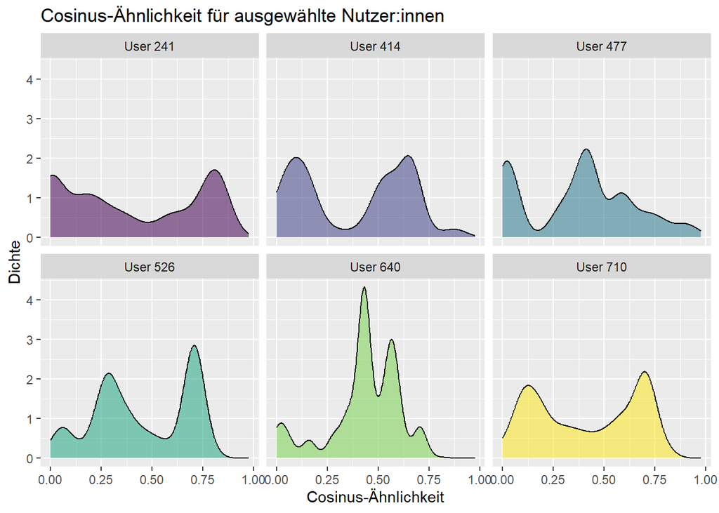

```r
userlist <- c(241, 414, 477, 526, 640, 710)

df_csim_long %>% filter(user %in% userlist) %>%
  ggplot(aes(value, fill = user, alpha = 0.5))+
  geom_density()+
  labs(x = "Cosinus-Ähnlichkeit",
       y = "Dichte",
       title = "Cosinus-Ähnlichkeit für ausgewählte Nutzer:innen",
       color = "User")+
  facet_wrap(~paste("User",user))+
  theme(legend.position = "none")  +
  scale_fill_viridis(discrete = TRUE)
```

Wir haben 6 sehr unterschiedliche Dichte-Profile. User 241, 414 und 477 alle haben eher eine Häufung Nahe 0 (also viele sehr kleine Werte) und dann wieder Höhen in der Mitte - gegen das obere Ende nimmt es dann wieder ab. Dies deutet darauf hin, dass sie eher spezifische Genres mögen und nicht einfach alles ein bisschen - Filme, deren Genres also nicht im User-Profil vorkommen sorgen für tiefe Ähnlichkeiten.

Wenn wir uns User 640 anschauen scheint dieser eher ein Allrounder zu sein. Sehr wenig tiefe Werte aber sehr viele Werte nahe der Mitte deuten darauf hin, dass diese Person eigentlich fast alle Filmgenres mag.

Bei User 710 & 526 scheint das ebenfalls der Fall zu sein: auch hier gibt es wenige Werte nahe 0. Der Unterschied zwischen User 526 und 710 scheint darin zu sein, dass User 526 vermutlich eher Comedy & Drama Filme mag (da wir ja bereits festgestellt haben, dass das die häufigsten Genres sind und daher der Spike eher weit rechts ist).

Bei User 710 gibt es wenige Werte bei 0 aber die erste Häufung bei ca. 0.1 - diese Person hat also vermutlich fast alle Genres mal geliked, auch diejenigen die nicht allgemein beliebt sind.

Wir überprüfen diese Vermutungen indem wir uns die Nutzerprofile anschauen:

```r
rownames_to_column(as.data.frame(m_user_genre), "User")%>%
  filter(User %in% userlist)
```

| User | unknown | Action | Adventure | Animation | Children's | Comedy | Crime | Documentary | Drama | Fantasy | Film-Noir | Horror | Musical | Mystery | Romance | Sci-Fi | Thriller | War | Western |
| --- | --- | --- | --- | --- | --- | --- | --- | --- | --- | --- | --- | --- | --- | --- | --- | --- | --- | --- | --- |
| 241 | 0 | 2 | 0 | 0 | 0 | 0 | 1 | 0 | 7 | 0 | 0 | 2 | 0 | 1 | 2 | 0 | 3 | 1 | 0 |
| 414 | 0 | 2 | 0 | 0 | 0 | 1 | 4 | 0 | 9 | 0 | 1 | 2 | 0 | 2 | 2 | 2 | 8 | 1 | 0 |
| 477 | 0 | 1 | 0 | 0 | 0 | 21 | 0 | 0 | 15 | 0 | 0 | 0 | 2 | 0 | 25 | 0 | 2 | 0 | 0 |
| 526 | 0 | 6 | 2 | 2 | 1 | 6 | 5 | 1 | 15 | 0 | 1 | 1 | 0 | 1 | 5 | 4 | 8 | 2 | 0 |
| 640 | 0 | 29 | 12 | 2 | 3 | 38 | 11 | 0 | 29 | 0 | 3 | 2 | 4 | 3 | 19 | 10 | 24 | 5 | 0 |
| 710 | 0 | 12 | 4 | 4 | 5 | 4 | 11 | 0 | 28 | 0 | 4 | 3 | 4 | 6 | 7 | 6 | 16 | 6 | 1 |

In der Tabelle scheint sich unsere Vermutung zu bestätigen; wir visualisieren das noch mit einem Plot:

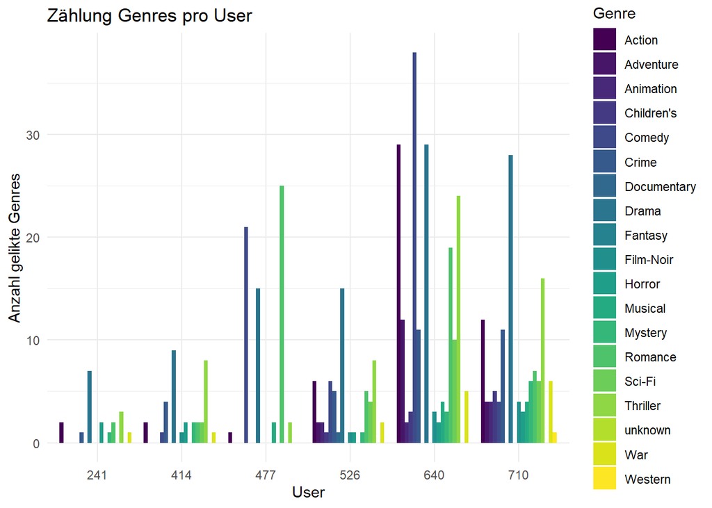

```r
rownames_to_column(as.data.frame(m_user_genre), "User")%>%
  filter(User %in% userlist) %>%
  mutate(User = as.factor(User)) %>%
  pivot_longer(!User, names_to = "Genre", values_to = "values") %>%
  ggplot(aes(User, values, fill = Genre))+
  geom_col(position = "dodge")+
  labs(title = "Zählung Genres pro User",
       y = "Anzahl gelikte Genres")+
  scale_fill_viridis(discrete = TRUE)+
  theme_minimal()
```

### 7.3 Empfehlbare Filme [6 Punkte]

#### 1. Bewertete Filme maskieren, d.h. “Negativabzug” der User-Items Matrix erzeugen, um anschliessend Empfehlungen herzuleiten.

Wir setzen alle nicht gerateten Filme auf 1 und alles, was eine Bewertung hat auf 0 - so wissen wir, welche Filme die Nutzer nicht geschaut haben. Die Sumem der 1er muss der Summe der NAs im ursprünglichen Datensatz entsprechen:

```r
df_neg <- df_user_ratings %>%
  modify(~ ifelse(is.na(.), 1, 0))

#prüfen, ob Anzahl NAs im ursprünglichen Dataframe der Anzahl 1er entspricht im Negativabzug (sollte 0 ergeben)
sum(is.na(df_user_ratings)) - sum(df_neg == 1)
```

```
## [1] 0
```

Da der Wert 0 ist sollte es stimmen.

#### 2. Zeilensumme des “Negativabzuges” der User-Items Matrix für die User “5”, “25”, “50” und “150” ausgeben.

```r
users_neg <- c(5,25,50,150)
df_neg_rowsum <- as.data.frame(rowSums(df_neg[users_neg,])) %>%
  `colnames<-`("Anzahl") %>%
  rownames_to_column("User") %>%
  arrange(Anzahl)

print(df_neg_rowsum)
```

```
##   User Anzahl
## 1    5   1489
## 2   25   1586
## 3  150   1633
## 4   50   1641
```

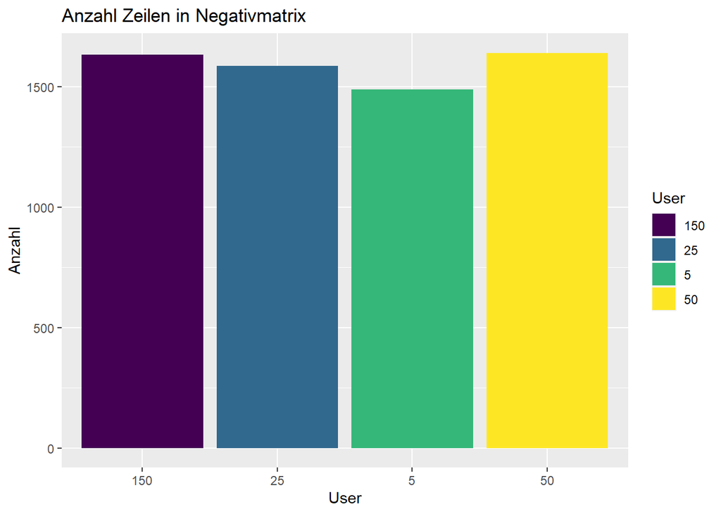

```r
ggplot((df_neg_rowsum), aes(User, Anzahl, fill = User))+
  geom_col()+
  labs(title = "Anzahl Zeilen in Negativmatrix")+
  scale_fill_viridis(discrete = TRUE)
```

#### 3. 5-Zahlen Statistik der Zeilensumme des “Negativabzuges” der User-Items Matrix bestimmen.

```r
stats(df_neg[users_neg,])
```

| Min | 25% | Median | 75% | Max | Mean | NAs |
| --- | --- | --- | --- | --- | --- | --- |
| 0 | 1 | 1 | 1 | 1 | NA | 0 |

### 7.4 Top-N Empfehlungen [12 Punkte]

#### 1. Matrix für Bewertung aller Filme durch element-weise Multiplikation der Matrix der Cosinus-Ähnlichkeiten von Nutzern und Filmen und “Negativabzug” der User-Items Matrix erzeugen.

Vor der Multiplikation überprüfen wir die Dimensionen der beiden Matrizen:

```r
print(paste("Dimension der Negativmatrix: ", dim(df_neg)[1], dim(df_neg)[2]))
```

```
## [1] "Dimension der Negativmatrix:  943 1664"
```

```r
print(paste("Dimension der Cosinus-Ähnlichkeitsmatrix: ", dim(m_csim_user_movie)[1], dim(m_csim_user_movie)[2]))
```

```
## [1] "Dimension der Cosinus-Ähnlichkeitsmatrix:  943 1664"
```

```r
m_neg_csim <- as(df_neg, "matrix") * m_csim_user_movie
```

#### 2. Dimension der Matrix für die Bewertung aller Filme prüfen.

```r
print(paste("Dimension der Matrix nach der elementweisen Multiplikation: ", dim(m_neg_csim)[1], dim(m_neg_csim)[2]))
```

```
## [1] "Dimension der Matrix nach der elementweisen Multiplikation:  943 1664"
```

Wie erwartet, haben wir die exakt gleichen Dimensionen wie vor der Multiplikation.

#### 3. Top-20 Listen extrahieren und Länge der Listen pro Nutzer prüfen.

Als nächstes wollen wir die Top20 Empfehlungen für alle User ausfindig machen. Dazu nutzen wir unsere Funktion:

```r
df_top20 <- get_topn_recos(m_neg_csim, 20)

df_counted <- df_top20 %>% group_by(user) %>% count()

head(df_counted, 5)
```

| user | n |
| --- | --- |
| 1 | 20 |
| 10 | 20 |
| 100 | 20 |
| 101 | 20 |
| 102 | 20 |

```r
stats(df_counted$n)
```

| Min | 25% | Median | 75% | Max | Mean | NAs |
| --- | --- | --- | --- | --- | --- | --- |
| 20 | 20 | 20 | 20 | 20 | 20 | 0 |

Wie wir dem Summary entnehmen können ist die Anzahl immer 20 für alle User.

#### 4. Verteilung der minimalen Ähnlichkeit für Top-N Listen für N = 10, 20, 50, 100 für alle Nutzer visuell vergleichen.

Um die Scores zu vergleichen benutzen wir Histogramme:

```r
Ns <- c(10, 20, 50, 100)
analyze_topn_recos(m_neg_csim, Ns)
```

```
## [[1]]
## # A tibble: 3,772 x 3
##    user  min_score     N
##    <chr>     <dbl> <dbl>
##  1 1         0.769    10
##  2 1         0.766    20
##  3 1         0.766    50
##  4 1         0.662   100
##  5 10        0.786    10
##  6 10        0.749    20
##  7 10        0.749    50
##  8 10        0.709   100
##  9 100       0.832    10
## 10 100       0.832    20
## # i 3,762 more rows
##
## [[2]]
```

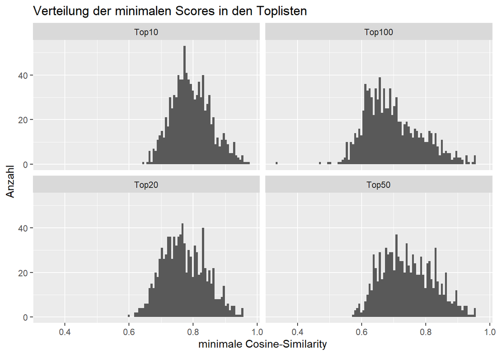

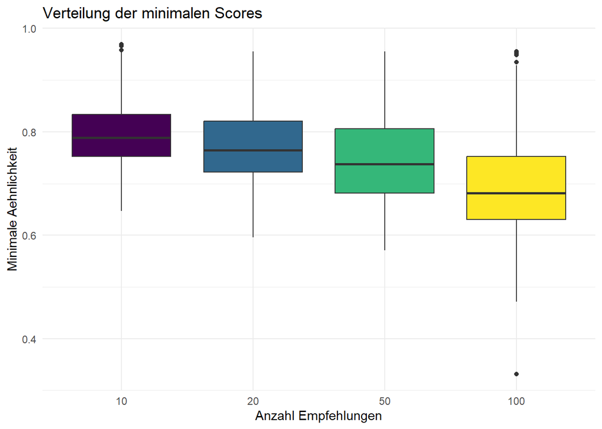

Sowohl im Histogram wie auch in den Boxplot sehen wir, dass mit zunehmendem N auch mehr tiefe Ähnlichkeiten dazu kommen. Das macht Sinn, da die Empfehlungen ja “schlechter” werden je tiefer man in der Rangliste absteigt. Ausserdem nimmt die Varianz zu; bei kleinem N haben die Empfehlungen eine sehr ähnlichen Ähnlichkeitsscore. Dies kommt daher, da User in der Regel ja Filme mit den Genres vorgeschlagen bekommen die sie bisher gemocht haben.

Wenn der Genre-Mix identisch ist zwischen Filmen, dann ist deren Ähnlichkeit auch identisch. Bei zunehmendem N haben wir vermehrt Filme die vielleicht ein etwas anderen Genre-Mix enthalten und daher auch einen anderen Ähnlichkeits-Score haben.

#### 5. Top-20 Empfehlungen für Nutzer “5”, “25”, “50”, “150” visualisieren.

Als letztes wollen wir noch die Empfehlungen mit den Nutzerprofilen vergleichen. Dazu erstellen wir einen Cleveland-Plot der den Mix aus Genres in den Nutzerprofilen mit dem Mix der Genres in den Empfehlungen vergleicht.

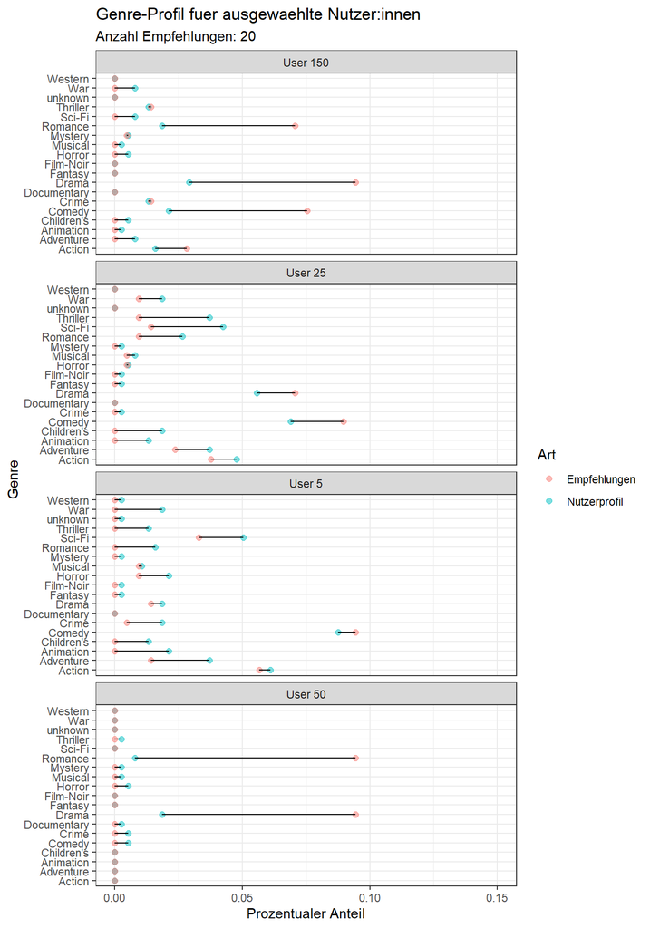

```r
create_cleveland_plot(users = users_neg, Ns = c(20))+
  facet_wrap(ncol = 1, ~paste("User", user))+labs(subtitle = "Anzahl Empfehlungen: 20")+
   scale_x_continuous(limits = c(0,0.15))
```

Wenn wir uns die Cleveland Plots der verschiedenen Nuzter:innen anschauen, so sehen wir, dass bei User 150 als Empfehlungen nur die Genres vorkommen, die den grössten Anteil am Nutzerprofil hatten. Alle anderen Genres wurden eher vernachlässigt. Bei diesem User sind die häufigsten Genres die in den Filmen vorkommen der Hautpbestandteil der Empfehlungen: Comedy, Romance, Drama und Action.

Bei User 25 hat es ebenfalls ein Bias zugunsten der beiden am häufigsten vorkommenden Genres im Nutzerprofil.

Bei User 5 hingegen wurde nur Comedy mehr empfohlen als im Nuzterprofil vorkam - alle anderen Genres wurden deutlich weniger empfohlen als der User sie im Profil hatte. Bei User 50 ist wieder ein sehr starker Bias zu Romance und Drama.

Ein möglicher Grund für diesen starken Bias ist, dass wir zum einen schlichtweg mehr Filme mit diesen Genres haben und zum anderen, dass beide Genres sehr wenig in Kombination mit anderen Genres vorkommt. Wenn der Recommender also denkt der User mag Drama & Romance, dann bekommt er Filmempfehlungen, die nur diese Genres haben. Wenn der User jedoch beispielsweise Adventure mag, ist die Vielfalt der Genres in den Empfehlungen deutlich höher, da dieses Genre selten alleine vorkommt.

#### 6. Für Nutzer “133” und “555” Profil mit Top-N Empfehlungen für N = 20, 30, 40, 50 analysieren, visualisieren und diskutieren.

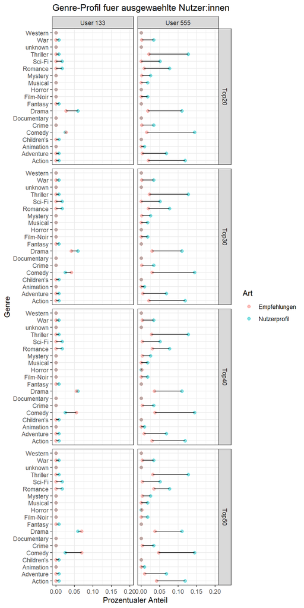

###### User 133: Wenn wir die Entwicklung der Cleveland Plots mit zunehmenden Empfehlungen anschauen, so fällt auf, dass zuerst die empfohlenen Genres weniger sind als im Nutzerprofil vorhanden. Der Recommender empfiehlt hier vor allem Drama und Comedy, beide mit dem gleichen Anteil. Spannend ist es, dass mit zunehmenden Anzahl Empfehlungen eigentlich nur die Empfehlungen für Drama und Comedy zunehmen; alle anderen Genres scheinen unverändert zu bleiben.

###### User 555:

Dieser User hat eine deutlich grössere Variation in den Genres als User 133. Vermutlich unter anderem, weil er Genres hat, die gerne kombiniert werden wie Action, Adventure und Comedy. Hier scheint sich der Genre-Mix auch mit zunehmenden N nicht grossartig zu ändern. Da wie erwähnt viele der Genres solche sind, die auch in vielen verschiedenen Filmen vorkommen, erstaunt das also nicht.

Allgemein scheint in beiden Fällen die Vielfalt an Genres nicht zuzunehmen bei zunehmender Anzahl Genres. Dies ist auch ein grosser Nachteil von Content based Recommendern: die Empfehlungen werden immer nur so sein wie die bisher gelikten Sachen. Neuentdeckungen sind mit Content based Recommendern nicht möglich. Das wäre also ein Vorteil für Collaboration Based Recommender. Im Idealfall sollte man aber für eine korrekte Implementation von Recommendern wenn möglich Ansätze aus verschiedenen Modellen nutzen, um die Schwächen der einzelnen Systeme auszugleichen.

### Learnings aus der Challenge

Bei Content Based Recommendern ist es unglaublich wichtig, welche Variablen für die Erstellung des Item Profils verwendet werden und auch wie sich die Werte darin verteilen. Wenn es Items hat, die nur eine einzige Ausprägung der Variable haben, schränken diese nachher die Empfehlungen übermässig ein; da - wenn der User eine Präferenz für ein solches Item zeigt - nur noch genau diese Kategorie empfohlen wird, da die Ähnlichkeit zu anderen Kombinationen zu tief ist. Interessant wäre es noch gewesen User zu analysieren die Genres mögen die im Datensatz kaum vorkommen; wie würde der Recommender dort Empfehlungen machen wenn nicht genügend nicht geratete Items vorhanden sind um 50 Items zu empfehlen?

### Nutzung von ChatGPT

Der wichtigste Punkt wofür ich ChatGPT genutzt habe war, um die Spalte mit den Genre-Kombis bei den Filmen zu erzeugen. Ansonsten habe ich ChatGPT nur zum Debugging benutzt. Statt ChatGPT habe ich auch viel gegoogelt - die Funktion für die Cosine Similarity kam auch durch eine Google Suche zustande, da meine erste Implementation nicht geklappt hat. Persönlich google ich lieber zuerst selber, da der Code von ChatGPT gerade in R häufig nicht besonders gut ist und ich auch häufig nicht verstehe, was der Code jetzt genau macht. (für die Genre-Kombis kann ich schon etwa sagen, was genau passiert - aber ich habe den Verdacht, dass es auch deutlich einfacher ginge.)